# scRICA: an R package for multiple-sample **s**ingle-**c**ell **R**NA-Seq **I**ntegrative **C**omparative **A**nalysis

Yan Li

2023-03-20

## 1. What is scRICA

It is a systematic workflow R package for integrative and comparative scRNA-seq analysis. Various parameter options are inputted from a metadata table and then inherited through the entire analysis workflow. scRICA can significantly improves efficiency of programming for comparative analyses with multiple sample attributes. It is distributed as an R package and also offers a command line execution option.

scRICA categorizes the workflow of integrative and comparative analysis using multiple-sample scRNA-seq data into four steps as shown below picture:

[figure not shown]

- **Step 1:** Pre-processing and quality control;
- **Step 2:** Multi-sample integration;
- **Step 3:** Visualization by attribute groups;
- **Step 4:** Downstream analysis including differential expression (DE) analysis, pseudo-time trajectory analysis, and cell clusters identification.

## 2. pacakge installation

### 2.1 Prerequisite packages installation

If below prerequisite packages have not been installed, you can install them via below commands:

```
BiocManager::install("MAST")
BiocManager::install("scater")
BiocManager::install("destiny")
install.packages("mclust")
install.packages("easylabel")
install.packages("corrplot")
devtools::install_github('EDePasquale/DoubletDecon')
devtools::install_github("ChenMengjie/lightHippo")
BiocManager::install("slingshot")
BiocManager::install("DESeq2")
BiocManager::install("SingleCellExperiment")
BiocManager::install("tradeSeq")
```

### 2.2 scRICA installation

- github installation

  ```
  devtools::install_github(repo = 'yan-cri/scRICA', build_vignettes = T, force = T)
  library(scRICA)
  ```

- Installation by downloading scRICA into your local computer via `git clone https://github.com/yan-cri/scRICA.git`, then install this package by:

  ```
  devtools::install('scRICA', build_vignettes = T)
  browseVignettes(package = 'scRICA')
  ```

## 3. Demonstration data

### 3.1 Demonstration data for multi-sample pre-processing and integration

As shown in below, a total of 6 samples single cell gene expression count matrix results from cell ranger analysis can be downloaded from https://drive.google.com/drive/folders/1wwxmi4cvASRDFtiFKs6MbflFDOOxw3AY?usp=sharing using as the demonstration data for this package’s **step 1** and **step 2** analysis implementations.

```
-- 3041A
   |__barcodes.tsv
   |__genes.tsv
   |__matrix.mtx
-- 3041F
   |__barcodes.tsv
   |__genes.tsv
   |__matrix.mtx
-- 3041I
   |__barcodes.tsv
   |__genes.tsv
   |__matrix.mtx
-- 3396A
   |__barcodes.tsv.gz
   |__features.tsv.gz
   |__matrix.mtx.gz
-- 3396F
   |__barcodes.tsv.gz
   |__features.tsv.gz
   |__matrix.mtx.gz
-- 3396I
   |__barcodes.tsv.gz
   |__features.tsv.gz
   |__matrix.mtx.gz
```

### 3.2 Demonstration data example of an integrated RDS

This RDS file can be downloaded from https://drive.google.com/drive/folders/1wwxmi4cvASRDFtiFKs6MbflFDOOxw3AY?usp=sharing, which can be used as demonstration data for scRICA **step 3** visualization and **step 4** downstream analysis implementations.

## 4. Input metadata table

### 4.1 metadata table specification

- In general, the input metadata table includes four mandatory columns: `sample`, `path`, `expCond1`, `doubletsRmMethod`.
  1. column `sample`: specifies all sample names which will be used for integration;
  2. column `path`: specifies the full path of count matrix for each corresponding sample in a row, where the processed count matrix can be in different formats, including 1). a processed count matrix saved in a folder as above downloaded data, which is directly generated from the 10X genomic Cell Ranger analysis tool; 2). a count matrix stored in text or hd5 format.
  3. column `doubletsRmMethod`: specify the doublet removal with 4 options, 1) None: no doublet removal; 2) centroids: one algorithm used for doublets removal from DoubletDecon; 3) medoids: another algorithm used in DobuletDecon for doublets identification; 4) OL, cells detected as doublets by both algorithm (centroids & medoids) from DoubletDecon.
  - Doublets detection step also can be done separately with a similar metadata table by function `findDoublets()` or command line option `Rscript run_scRICA_findDoublets.R --options`, which only `sample` and `path` are required as mandatory columns
  - If doublets detection step is done separately, we can use column `doubletsResDir` to specify the full path of DoubletDecon results directory.
  4. column `expCond1`: specify sample’s attributes under an experimental condition, such as our demonstration data, it can be the fallopian tube anatomical side (I/A/F)
- Extra columns can be added to provide more options, they are:
  1. `expCond*': specify more sample's attributes, they will be inherited into the integrated Seurat object as`expCond2`,`expCond3`,`expCond4` …
  2. `filterFname`: the full path of a file, which includes all cells in the rows specified with column `barcode` and extra column `filter’ with True or False to specify whether the cell in a row need to be removed.

### 4.2 metadata table examples

- For our provided total of 6 demonstration data for integration, metadata table can be specified as:

| sample | path | expCond1 | expCond2 | doubletsRmMethod |
| --- | --- | --- | --- | --- |
| 3041A | /FullPath/to/CountMatrix/ | A | patient1 | OL |
| 3041F | /FullPath/to/CountMatrix/ | F | patient1 | OL |
| 3041I | /FullPath/to/CountMatrix/ | I | patient1 | OL |
| 3396A | /FullPath/to/CountMatrix/ | A | patient2 | OL |
| 3396F | /FullPath/to/CountMatrix/ | F | patient2 | OL |
| 3396I | /FullPath/to/CountMatrix/ | I | patient2 | OL |

Where you can see that ‘OL’ doublets removal method is specified in column `doubletsRmMethod` for all samples, you can also specify different methods in that column for each sample, because doublet removal is conducted on samples separately.

- If doublets removal step is done separately, the metadata table for doublet removal step can be:

| sample | path |
| --- | --- |
| 3041A | /FullPath/to/CountMatrix/ |
| 3041F | /FullPath/to/CountMatrix/ |
| 3041I | /FullPath/to/CountMatrix/ |
| 3396A | /FullPath/to/CountMatrix/ |
| 3396F | /FullPath/to/CountMatrix/ |
| 3396I | /FullPath/to/CountMatrix/ |

- Then the metadata table for integration can be changed into:

| sample | path | expCond1 | expCond2 | doubletsRmMethod | doubletsResDir |
| --- | --- | --- | --- | --- | --- |
| 3041A | /FullPath/to/CountMatrix/ | A | patient1 | OL | /FullPath/to/DoubletDeconResults/ |
| 3041F | /FullPath/to/CountMatrix/ | F | patient1 | OL | /FullPath/to/DoubletDeconResults/ |
| 3041I | /FullPath/to/CountMatrix/ | I | patient1 | OL | /FullPath/to/DoubletDeconResults/ |
| 3396A | /FullPath/to/CountMatrix/ | A | patient2 | OL | /FullPath/to/DoubletDeconResults/ |
| 3396F | /FullPath/to/CountMatrix/ | F | patient2 | OL | /FullPath/to/DoubletDeconResults/ |
| 3396I | /FullPath/to/CountMatrix/ | I | patient2 | OL | /FullPath/to/DoubletDeconResults/ |

## 5. Analysis Workflow implementation

### 5.1: ‘Step 1’ data pre-processing and quality control(QC)

  ```
  library(scRICA)
  qcResult <- processQC(metadata = metadata, resDirName = 'scRICA_test_result', genomeSpecies = 'human', mtFiltering = T, mtPerCutoff = 20)
  ```

- Options for this function includes:
  - `genomeSpecies`: specify sample’s genome species, by default ‘human’, currently supporting human, mouse, and rate.
  - `extraFilter`: True or False option, if ‘TRUE’, column ‘filterFname’ needs to be included in the provided metadata table.
  - `minCells`: specify the minimum detected number of cells to be included in the analysis for each sample used by Seurat, by default = 3.
  - `minFeatures`: specify the minimum number of expressed gene features for cells included in the analysis used by Seurat, by default = 200.
  - These options can also be checked with `?processQC`
- Results will be saved into the folder specified in the option `resDirName` under the current working directory shown as below data structure, where includes 2 directories and 3 text files.

  - Directory ‘doublet_results’ include the doublets detection results;
  - Directory ‘QC_plots’ contains all quality assessment results with respect to each sample in the metadata table;
  - Text file ‘MT_percentage_summary.txt’ presents a summary of mitochondrial content percentage for all samples;
  - Text file ‘org_doubletsRemoval_cellNoSummary.txt’ shows a summary of number of cells before and after doublets removal;
  - Text file ‘No_filtered_cells_summary.txt’ presents number of cells before and after mitochondrial content filtering, if option `mtFiltering = T`.

### 5.2: ‘Step 2’ Data integration

- This step integrates all samples listed in the input metadata table using two popular integration methods, the CCA and RPCA algorithms in Seurat, the input file for this function is the pre-processed QC results from above ‘step 1’ for example:

  ```
  results <- getClusterMarkers(qcProcessedResults = qcResult)
  ```

- Options for this function includes:
  - `integrationMethod`: specify integration method applied for anchor identification for integration, 2 options, ‘CCA’ and ‘RPCA’, by default = ‘CCA’.
  - `nfeatures`: specify the number of identified over expressed genes from each identified cell clusters, by default = 10.
  - `topN`: specify the folder/directory name where integration analysis results will be saved, by default: the save directory where QC results are saved.
  - `ribo`: True or False logical option, if True, rRNA genes are removed from the variable features for integration analysis.
  - `int.k.weight`: specify the number of neighbors to consider when weighting anchors in the step of integration, by default = 100, if too few number cells used in the study, this number can be reduced.
- The integration results will be saved in the same directory defined in the `processQC()` execution, here we can see:
  - A folder named as ‘RDS_Dir’, where the integration RDS file is saved.
  - Several other results files and figures from integration analysis:
    - ‘umap_plot.pdf’: multi-sample integrated UMAP plot;
    - ‘tsne_plot.pdf’: multi-sample integrated tSNE plot:
    - Corresponding UMAP and tSNE plots separated on samples from the input metadata table: ‘umap_plot_samplSep.pdf’ and ‘tsne_plot_samplSep.pdf’
    - ‘allCluster_pos_markers.txt’: identified over-expressed genes with respect to each identified cell cluster;
    - ‘allCluster_pos_markers_no.txt’: summarize the number of over-expressed genes from each identified cell cluster;
    - ‘allCluster_pos_markers_top10.txt’: presents `topN` identified over-expressed genes from each identified cell cluster;
    - ‘cluster_heatmap_top10PosMarkers.pdf’: a heatmap of `topN` identified over-expressed genes from each identified cell cluster.
    - ‘seuratReadin_qcProcessed.Rdata’: intermediate Rdata file, where the pre-processed QC results from step 1 is saved as an object named as `seuratProcssedObjList1`, which can be loaded and used for integration analysis separately, such as

      ```
      load(seuratReadin_qcProcessed.Rdata)
      results2 <- getClusterMarkers(qcProcessedResults = seuratProcssedObjList1, integrationMethod = 'RPCA')
      ```

### 5.3: Commannd line execution option for Step 1 and Step 2 analysis

- For our demonstration data, the step 1 and step 2 analysis can be combined together with below command line option to conduct by specifying the full path to the metadata table provide in above section 4.

```bash
Rscript run_scRICA_qc_integration.R -m PATH/TO/METADATA_TABLE -o scRICA_results -g human --minCells 3 --minFeatures 100 --mtFiltering True --mtPerCutoff 20 --multiomics False --extraFilter False --integration.method CCA --integration.nfeatures 500 > $PWD/run_scRICA.log 2>&1
```

### 5.4: ‘Step 3’ integrated results visualization

#### 5.4.1 Cellular compositions summary and visualization

1. These can be done via `getClusterSummaryReplot()`. In our demonstrated data named as ‘scRICA_demo.rds’, where ‘expCond1’ specify the patient donor IDs, and ‘expCond2’ specify fallopian tube anatomical sites (I/A/F). If you would like to update the cells annotation, just run on `newAnnotation=T`, and provide the corresponding annotation file with the option `newAnnotationRscriptName=/full/path/to/file`, an example of new annotation file named as `anno_example.R` can be found from ‘misc’ folder, where all cell types need to be updated can be included.

   An example code to summarize the cellular composition based on samples attribute specified in ‘expCond1’ with respect to different donors is shown below:

```
rds1 <- readRDS('~/Desktop/757_scRNA-seq/RDS/scRNAseq_FT_finalized_wAnno.rds')
library(scRICA)
## seperation on donor: expCond1
getClusterSummaryReplot(rds = rds1, resDir = 'scRICA_results', newAnnotation = F, expCondCheck = 'expCond1', expCondCheckFname = 'donors_summary')
## seperation on fallopian tissue types (I/A/F): expCond2 togher with new annotation
getClusterSummaryReplot(rds = rds1, resDir = 'scRICA_results', newAnnotation = T, newAnnotationRscriptName = 'anno_example.R', expCondCheck = 'expCond1', expCondCheckFname = 'donors_summary')
```

2. Depending on whether `newAnnotation` is True or False, all related results will be saved into `scRICA_results/results_wOrgClusterAnnotation/expCond_donors_summary` or `scRICA_results/results_wOrgClusterAnnotation/expCond_donors_summary` respectively. An example of data structure of result with `newAnnotation=F` can be seen as:

   ```
   -- scRICA_results
     |__results_wOrgClusterAnnotation
   |expCond_donors_summary
      |__cellNo_summary_orgClusterAnnotation_expCond_donors_summary.pdf
      |__cellNo_summary_orgClusterAnnotation_expCond_donors_summary.txt
      |__new_tSNE_plot_expCond_donors_summary
         |__tsne_plot_noLabel_integrate_orgAnnotation.pdf
         |__tsne_plot_wLabel_integrate_orgAnnotation.pdf
         |__tsne_plot_wLabel_orgAnnotation_expCond_donors_summary.pdf
      |__new_UMAP_plot_expCond_donors_summary
         |__UMAP_plot_noLabel_integrate_orgAnnotation.pdf
         |__UMAP_plot_wLabel_integrate_orgAnnotation.pdf
         |__UMAP_plot_wLabel_orgAnnotation_expCond_donors_summary.pdf
   ```

- where ‘cellNo_summary_orgClusterAnnotation_expCond_donors_summary.pdf’: is a cellular composition plot separated by the specified sample’s attribute by the option `expCondCheck = 'expCond1'`.
- ‘cellNo_summary_orgClusterAnnotation_expCond_donors_summary.txt’: provides a summary of corresponding cell number and percentage of cells normalized by the total number of cells from each attribute.
- cellular composition plot separated by patient donors (`expCondCheck = 'expCond1'`) is:

[figure not shown]

- cellular composition plot separated by fallopian tube anatomical sites (`expCondCheck = 'expCond2'`) with new cell annotation specified in `newAnnotation = T, newAnnotationRscriptName = 'anno_example.R'` is:

[figure not shown]

- UMAP plot separated into 3 different anatomical sites (I/A/F) together with new cell annotations is:

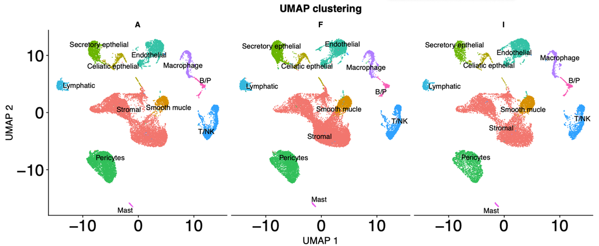

3. There are several options which can be used to alter the cellular composition percentage bar-plot, such as
   - `stack =T`: make stacked or un-stacked cellular composition bar-plot by turning on/off this option
   - `perPlotVertical = F`, either in the vertical or horizontal position for this cellular composition bar-plot
   - `fpRemake = F, perRemake = T`: only make cellular composition bar-plot by turn on `perRemake` without making corresponding UMAP/tSNE plots (`perPlotVertical = F`)
   - `perPlotVertical = F, perPlotHeight = 3, perPlotWidth = 7, fpRemake = F, stack =T`,
   - `expCondNameOrder = c('I', 'A', 'F')`: specify the order of attributes specified from `expCondCheck = 'expCond2'`, where ‘expCond2’ has 3 levels, which can be re-ordered as ‘I->A->F’.
   - An example of un-stacked re-ordered cellular composition plot shown below can be made by:

   ```
   getClusterSummaryReplot(rds = rds1, resDir = 'misc/visualization_results',
                      perRemake = T, fpRemake = F, stack =F,
                      perPlotVertical = T, perPlotHeight = 3, perPlotWidth = 7,
                      expCondNameOrder = c('I', 'A', 'F'),
                      newAnnotation = F,
                      expCondCheck = 'expCond2', expCondCheckFname = 'tissue_sep1')
   ```

[figure not shown]

4. Other options can be found from the help document via `?getClusterSummaryReplot`

##### 5.4.2 feature genes dot-plot visualization

1. This plot can be made via function `getGoiDotplot()`. A code example to make such plot on a list of cell cycle genes list (seen in `misc` folder named as ‘marker_genes_CC.xlsx’), which all cell cycle genes are classified into 2 groups: ‘S phase’ and ‘G2/M phase’.

   ```
   getGoiDotplot(resDir = 'misc/visualization_results', rds = rds1,
           newAnnotation = F,
           goiFname = 'misc/marker_genes_CC.xlsx',
           expCondCheck = 'expCond2', expCondCheckFname = 'dotplot_tissue',
           dotPlotFnamePrefix = 'cc')
   ```

2. scRICA provides options for users to select certain cell types `cellcluster` and/or experimental conditions based on the levels of chosen attribute in `expCondCheck = 'expCond2'` for this feature dot-plot visualization. For example, we can visualize only 3 T/NK cells (T/NK1, T/NK2, and T/NK2) from 2 fallopian tube tissues I and A via below command.

   ```
   getGoiDotplot(resDir = 'misc/visualization_results', rds = rds1,
           newAnnotation = F,
           goiFname = 'misc/marker_genes_CC.xlsx',
           expCondCheck = 'expCond2', expCondCheckFname = 'dotplot_tissue',
           geneTypeOrder = c('S phase', 'G2/M phase'),
           cellcluster = c('T/NK1', 'T/NK2', 'T/NK3'),
           expCond = c('I', 'A'),
           expCondReorderLevels = paste(rep(rev(c('T/NK1', 'T/NK2', 'T/NK3')), each=2), rep(rev(c('I', 'A')), time = 3), sep = '_'),
           dotPlotFnamePrefix = 'cc_TNKonly_IAonly',
           dotPlotMinExpCutoff = 0, dotPlotMaxExpCutoff = 4,
           dotPlotWidth = 26, dotPlotHeight = 6,
           legendPer = 0.08, genetypebarPer = 0.03,
           fontsize.x = 20, fontsize.y = 16,
           fontangle.x = 90, fontangle.y = 0,
           fontsize.legend1 = 10,
           geneTypeLegendOn = T, fontsize.legend2 = 20)
   ```

3. As shown in above code, there are several options which can be used to adjust this dot-plot display, including x-/y-axis font size and angles (`fontsize.x`, `fontangle.x` etc.), whether to include gene type legend color bar (`geneTypeLegendOn`), the size of the dot plot (`dotPlotWidth` and `dotPlotHeight`), top legend bar height (`genetypebarPer`) etc., for detailed information please refer the help manual `?getGoiDotplot`. And the finalized plot can be seen as this:

[figure not shown]

##### 5.4.3 heatmap visualization

1. This plot can be made via function `getGoiHeatmap()`. The heatmap can be visualized in 3 ways via option `heatmap.view`, including visualize on 1). the identified cell types by `heatmap.view = 'idents'`; 2) samples attributes levels by `heatmap.view = 'expCond'`; 3) across samples attributes levels with respect to different cell types by `heatmap.view = 'expCond.idents'`. Additionally, we also can make heatmap based on 1) cell levels with `display = 'cell'`; 2) aggregated expressions across various levels of samples attributes with `display = 'expCond.merge'`; 3) aggregated expressions for each sample defined in the metadata table with `display = 'sample.merge'`. For example, we can use below command to generate a heatmap of selected genes expression aggregated at the sample level across all cell types.

   ```
   getGoiHeatmap(heatmap.view = 'idents', resDir = 'misc/visualization_results', rds = rds1,
           newAnnotation = F, geneNames = c('CD44', 'ITGA6', 'EPCAM', 'KRT5', 'KRT7', 'TUBB4A', 'TUBB4B', 'PAX8'),
           expCondCheck = 'expCond2',
           expCondCheckFname = 'heatmap_tissue',
           plotFnamePrefix = 'geneset1_sampleMerge',
           display = 'sample.merge')
   ```

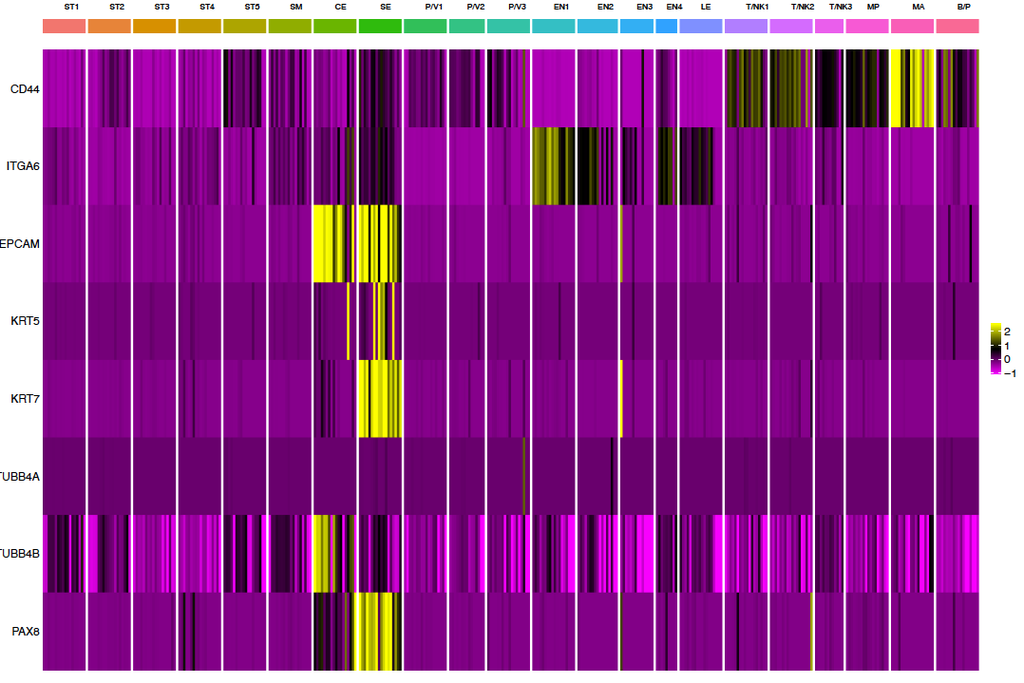

2. scRICA includes various options to change the plot size, font size etc. to make the figure with high resolution quality for publication, they can be found from the help manual via `?getGoiHeatmap`. Additionally scRICA also allows users to select certain cell types and samples attributes for heatmap visualization, here is an example of the heatmap from fallopian tube I and A for the selected genes on each sample level.

```
getGoiHeatmap(heatmap.view = 'expCond.idents', resDir = 'misc/visualization_results', rds = rds1,
            newAnnotation = F, geneNames = c('CD44', 'ITGA6', 'EPCAM', 'KRT5', 'KRT7', 'TUBB4A', 'TUBB4B', 'PAX8'),
            expCondCheck = 'expCond2',
            expCondCheckFname = 'heatmap_tissue',
            plotFnamePrefix = 'geneset1_expCond_idents_merge_SECEonly_IAonly',
            expCondReorderLevels = c('I CE', 'A CE', 'I SE', 'A SE'),
            display = 'sample.merge', draw.lines = F,
            cellcluster = c('CE', 'SE'),
            expCond = c('I', 'A'),
            fontsize.top = 2, fontsize.y = 12, barHeight.top = 0.05,
            plotWidth = 5, plotHeight = 3, fontangle.top = 90, debug = T)
```

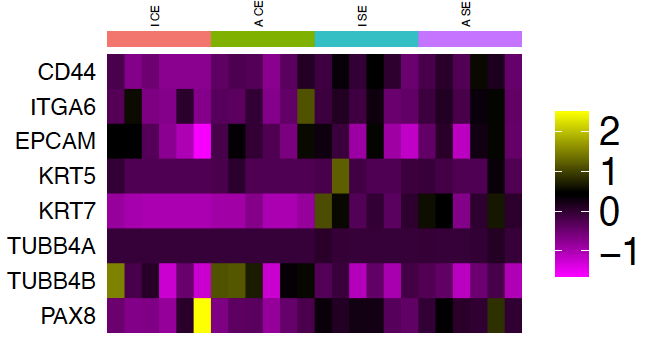

### 5.5: ‘Step 4’ downatream analysis

##### 5.5.1 Differential expression analysis between different samples attributes for cell types

- DE analysis on cells

  scRICA allow users to conduct DE analysis on any 2 group of cells with different sample’s attributes defined in any specific metadata table column (expCond*). For example, the demonstration RDs data has 2 columns, expCond1 and expCond2, defining samples attributes of donors and fallopian tissue types respectively. If we would like to check DEGs between tissue types I and F for a specific cell type with option `cellcluster` or all cell types without specifying `cellcluster`. Once you are running on all cell clusters, all cell types DE results are saved into the excel file spreadsheet, which can cause memory deficiency for excel file storage. commands to run these 2 analysis can be seen as below:

  ```
  de.res1 <- getClusterExpCondDe(resDir = 'misc/', rds = rds1,
                             newAnnotation = F,
                             cellcluster = 'MP', deMethod = 'wilcox',
                             expCondCheck = 'expCond2', expCondCheckFname = 'IFcomp_wilcox',
                             compGroup = 'I/F')
  ```

  ```
  de.res2 <- getClusterExpCondDe(resDir = 'misc/', rds = rds1,
                             newAnnotation = F, deMethod = 'MAST',
                             outputExcel = as.logical(F),
                             expCondCheck = 'expCond2', expCondCheckFname = 'IFcomp_allCells_MAST',
                             compGroup = 'I/F')
  ```

  ```
  -- results_wOrgClusterAnnotation_DEGs
     |__IFcomp_allCells_MAST
    |__expCondCompDeMarkers_I-F_adjSig_allClusters_cluster*.txt
    |__expCondCompDeMarkers_I-F_adjSig_down_allClusters_cluster*.txt
    |__expCondCompDeMarkers_I-F_adjSig_up_allClusters_cluster*.txt
    |__expCondCompDeMarkers_I-F_full_allClusters_cluster*.txt
    |__expCondCompDeMarkers_I-F_NoDEmarkers_summary.xlsx
    |__expCondCompDeMarkers_I-F_top10_downDe.xlsx
    |__expCondCompDeMarkers_I-F_top10_upDe.xlsx
     |__IFcomp_wilcox
    |__expCondCompDeMarkers_I-F_adjSig_1SelClusters.xlsx
    |__expCondCompDeMarkers_I-F_adjSig_down_1SelClusters.xlsx
    |__expCondCompDeMarkers_I-F_adjSig_up_1SelClusters.xlsx
    |__expCondCompDeMarkers_I-F_full_1SelClusters.xlsx
    |__expCondCompDeMarkers_I-F_NoDEmarkers_summary.xlsx
    |__expCondCompDeMarkers_I-F_top10_downDe.xlsx
    |__expCondCompDeMarkers_I-F_top10_upDe.xlsx
  ```

  Above returned DE analysis results are listed item, where you can access all DE analysis results with below command with `de.res1` as an example:

  ```
  head(de.res1$clusterDeMarkers$MP)
  de.res1$clusterDeResSummar
  head(de.res1$clusterTopDeMarkers$MP)
  ```

- DE analysis on sample’s pseudo-bulk counts

  scRICA also provides DE analysis based on pseudo-bulk counts aggregated on samples defined in the initial metadata table, this information is inherited into the integrated RDS metadata table column expCond (`rds1$expCond`). For example, in our demonstration RDS file, there are totally 18 samples from different donor fallopian tube tissues, then we can use option `deMethod = 'DESeq2.bulk'` to conduct pseudo-bulk DE analysis, where counts from each sample are aggregrated and normalized based on the total number of cells. Additionally, users can also use an addtional metadata table to specify certain confounding covariates for model to correct those potential confounding effects for DE analysis with DESeq2. In this confounding factor defining metadata table, 1) column `bulksamp` should include all samples listed in `rds1$expCond` or initial metadata table for integration analysis; 2) other confounding factors to be corrected should be included in the columns of this table, such as we make an example confounding factor metadata table for our RDS demonstration data as below, here we would like to address potential confounding factors effects from `gender` and `bmi`.

  ```
  meta1 <- data.frame('bulksamp' = names(table(rds1$expCond)),
                  'gender' = c('F', 'F', 'F', 'M', 'M', 'M', 'M', 'M', 'F', 'F', 'M', 'M', 'M', 'M', 'M', 'M', 'F', 'F' ),
                  'bmi' = c(23.5, 23.5, 23.5, 18, 18, 28.4, 28.4, 28.4, 32, 32, 20, 20, 20, 30, 30, 30, 21, 21))
  ```

  With this confounding factor metadata table, we can use option `deseq2bulk.metaCovariateInput` to remove all potential confounding factor effects from pseudo-bulk DE analysis performed via DESeq2. Users also can use option `norm.method` to adjust normalization methods implemented across samples, including TMM, upper-quantile (UQ), and default DESeq2 normalization methods. An example of running command can be seen as below:

  ```
  de.res3 <- getClusterExpCondDe(resDir = 'misc/', rds = rds1,
                             newAnnotation = F, cellcluster = 'MP',
                             deMethod = 'DESeq2.bulk',
                             deseq2bulk.metaCovariateInput = meta1,
                             expCondCheck = 'expCond2', expCondCheckFname = 'IFcomp_DEseq2bulk',
                             compGroup = 'I/F')
  ```

  In addition to above analysis results, scRICA also return original and cell number normalized count table, which users can use below command to access them:

  ```
  head(de.res3$normCounts$MP)
  head(de.res3$orgCounts$MP)
  ```

##### 5.5.2 Over expressed marker genes across comparison cell types with respect to different sample’s attributes levels.

scRICA allow users to check over expressed marker genes across defined cell types via function `getExpCondClusterMarkers()`. For example, users can check over-expressed genes among 5 selected immune cells, including T/NK1, T/NK2, T/NK3, MP, and B/P with respect to samples tissue types defined in `expCond2` with below command:

```
oe.res1 <- getExpCondClusterMarkers(resDir = 'misc/', rds = rds1,
                                    deMethod = 'MAST',
                                    cellcluster = c('T/NK1', 'T/NK2', 'T/NK3', 'MP', 'B/P'),
                                    newAnnotation = F,
                                    expCondCheck = 'expCond2',
                                    expCondCheckFname = 'tissue_IR_overExpressedGenes')
```

Where, over-expressed marker genes are identified from each cell type in comparison with all other cell types with respect to each fallopian tube tissue type (I/A/F). Similarly, as other DE results, all analysis results are also saved into the folder based on defined options `resDir`, `newAnnotation`, and `expCondCheckFname`. In our example, results are saved into the foler named as `misc/clusterMarkerGenes_results_wOrgClusterAnnotation` with below data structure, where 1) full list of marker genes analysis results with respect to each fallopian tube tissue type are saved into txt file named as `*_resFull.txt`; 2) significant over-expressed genes list are also saved into different txt file named as `*_UpSig.txt`; 3) the number of over-expressed marker genes are also summarized into `*_UpSig_NoSummary.txt`; 4) top expressed marker genes heatmap is also made with respect to different levels of samples attributes as `*_UpSig_heatmap.pdf`.

```
-- clusterMarkerGenes_results_wOrgClusterAnnotation
   |__tissue_IR_overExpressedGenes
      |__expCond_tissue_IR_overExpressedGenes_A_allCluster_pos_markers_resFull.txt
      |__expCond_tissue_IR_overExpressedGenes_A_allCluster_pos_markers_UpSig_heatmap.pdf
      |__expCond_tissue_IR_overExpressedGenes_A_allCluster_pos_markers_UpSig_NoSummary.txt
      |__expCond_tissue_IR_overExpressedGenes_A_allCluster_pos_markers_UpSig.txt
      |__expCond_tissue_IR_overExpressedGenes_F_allCluster_pos_markers_resFull.txt
      |__expCond_tissue_IR_overExpressedGenes_F_allCluster_pos_markers_UpSig_heatmap.pdf
      |__expCond_tissue_IR_overExpressedGenes_F_allCluster_pos_markers_UpSig_NoSummary.txt
      |__expCond_tissue_IR_overExpressedGenes_F_allCluster_pos_markers_UpSig.txt
      |__expCond_tissue_IR_overExpressedGenes_I_allCluster_pos_markers_resFull.txt
      |__expCond_tissue_IR_overExpressedGenes_I_allCluster_pos_markers_UpSig_heatmap.pdf
      |__expCond_tissue_IR_overExpressedGenes_I_allCluster_pos_markers_UpSig_NoSummary.txt
      |__expCond_tissue_IR_overExpressedGenes_I_allCluster_pos_markers_UpSig.txt
```

Similarly, some analysis results can also be accessed from returned analysis object, including the full list of over-expressed genes and significantly over-express gene list, such as `oe.res1` from our above analysis example.

```
head(oe.res1$fullRes$A)
head(oe.res1$sigUp$A)
table(oe.res1$sigUp$A$cluster)
```

##### 5.5.3 HIPPO cells sub-clustering analysis

scRICA allow users to conduct sub-clustering HIPPO analysis for any specific cell types (`cellcluster`) with respect to cell from all samples or any specific sample’s attribute defined via `expCondCheck` and `expCond` together. This analyis can be done inside R with R function `getHippoRes()` or by command line exections `Rscript run_scRICA_hippo.R [Options]...`.

- R function exectution: `?getHippoRes()`

  ```
  getHippoRes(resDir = 'misc/', rds = rds1, newAnnotation = F,
          hippoResNamePrefix = 'Allcells_TNK',
          cellcluster = c('T/NK1', 'T/NK2', 'T/NK3'), noClusters = 4)
  ```

  Users also can conduct HIPPO sub-clustering analysis on cells defined from a specific sample’s attribute level, such as you can conduct HIPPO sub-clustering analysis on 2 groups of T/NK cells from fallopian tissue `F` only via below command:

  ```
  getHippoRes(resDir = 'misc/', rds = rds1, newAnnotation = F,
          expCondCheck = 'expCond2', expCond = 'F',
          hippoResNamePrefix = 'Fonly_TNK23',
          cellcluster = c('T/NK2', 'T/NK3'), noClusters = 5)
  ```

  If too many cells need to be performed, you also can turn on `sparseMatrix = T` to avoid memory deficiency. The HIPPO analysis results are saved into the defined folder named via option `hippoResNamePrefix` inside `resDir` direcotry sub-folder `hippo_results`, an example of above analysis results data structure can be seen as below:

  ```
  -- hippo_results
     |__Allcells_TNK
    |__Allcells_TNK_k4_clustersTree.pdf
    |__diagnosticPlot_cellCluster_Allcells_TNK_k4.pdf
    |__lightHIPPOres_Allcells_TNK_k4.Rdata
    |__Per_cellCluster_Allcells_TNK_k4.xlsx
    |__topFeatures_cellCluster_Allcells_TNK_k4_dotplot.pdf
     |__Fonly_TNK23
    |__...
  ```

  where includes 1) hierarchy clustering tree plot; 2) diagnostic clustering plot; 3) all analysis results saved in Rdata; 4) number of cells in each HIPPO identified sub-clusters in excel file; 5) top expressed genes with respect to each HIPPO identified sub-clusters.
- Command line execution: `Rscript run_scRICA_hippo.R --help`

  Users can also conduct above analysis with command line executions as below:

  ```bash
  Rscript run_scRICA_hippo.R --outputDir misc/ --hippoResNamePrefix Allcells_TNK_commandLine --expCondCheck 'all' --rdsFname ~/Desktop/scRICA_demo.rds --cellclusters 'T/NK1, T/NK2, T/NK3' --noCluster 4 > $PWD/run_scRICA_hippo_tnk_allcells_k4.log 2>&1
  ```

  ```bash
  Rscript run_scRICA_hippo.R --outputDir misc/ --hippoResNamePrefix Fonly_TNK23_commandLine --expCondCheck 'expCond2' --expCond 'F' --rdsFname ~/Desktop/scRICA_demo.rds --cellclusters 'T/NK2, T/NK3' --noCluster 5 > $PWD/run_scRICA_hippo_tnk23_Fonly_k5.log 2>&1
  ```

- Update RDS file with HIPPO results

  As shown in above examples, 3 types of T/NK cells were conducted with sub-clustering analysis with HIPPO for a k=4 sub-clusters identification. Below command can be used to update the cells clustering information saved in `Idents()` based on HIPPO results saved in `Rdata` format. If list names are provided in the option `hippoResList`, updated cells idents names are based on them. Otherwise, users also can use option `hippoResNames` for updated HIIPO sub-clusters names. More detailed information regarding to these options, please refer `?updateHippoIdents`.

  ```
  rds.hippo1 <- updateHippoIdents(resDir = 'misc/', rds = rds1, resSaveFname = 'hippo_tnk.Rds',
                           hippoResList = list('TNK_hippo' = 'misc/hippo_results/Allcells_TNK_k4/lightHIPPOres_Allcells_TNK_k4.Rdata'),
                           hippoResK = c(4),
                           newAnnotation = F )
  table(Idents(rds.hippo1))
  ```

##### 5.5.4 pseudo-time trajectory analysis with slingshot

Similarly, scRICA also allow users to conduct pseudo-time trajectory analysis with slingshot for any specific cell types (cellcluster) with respect to cells from all samples or any specific sample’s attribute defined via expCondCheck and expCond together. This analyis can be done inside R with R function `getExpCondClusterPseudotime()` or by command line exections `Rscript run_scRICA_pseudoTime.R [Options]...`.

- R function exectution: `?getExpCondClusterPseudotime()`. For example, you can run slingshot pseudo-time trajectory analysis on SE and CE cell types with respect to 3 different fallopian tube anatomical sites seperations with below command:

- The above analysis results are saved inside folder named via options `resDir` and `expCondCheckFname`. For example, the above analysis results are saved into the folder named as `./misc/visualization_results/results_wOrgClusterAnnotation_pseudoTime/tissueSep_SECE` with below data structure:

  ```
  -- results_wOrgClusterAnnotation_pseudoTime
   |__tissueSep_SECE
    |__expCondLevel_A_cluster_SE_fnPseudoTimeRes.Rdata
    |__expCondLevel_A_cluster_SE_ptGMM_GAMheatmap.pdf
    |__expCondLevel_A_cluster_SE_ptGMM_GAMheatmapGenenames.txt
    |__expCondLevel_A_cluster_SE_ptGMM_lineage.pdf
    |__expCondLevel_A_cluster_SE_ptGMM_plots.pdf
    |__...
  ```

  where includes results with respect to each samples attributes condition and cell types, such as for fallpian site ampulla, SE cell, 1) slingshot linage plots (`expCondLevel_A_cluster_SE_ptGMM_lineage.pdf`); 2) PCA and diffusion map seperation plots (`expCondLevel_A_cluster_SE_ptGMM_plots.pdf`); 3) heatmap of identified genes seperating lingeages (`expCondLevel_A_cluster_SE_ptGMM_GAMheatmap.pdf`); 4) corresponding gene list presented in heatmap (`expCondLevel_A_cluster_SE_ptGMM_GAMheatmapGenenames.txt`).
- Command line execution: `Rscript run_scRICA_pseudoTime.R --help`

  For above analysis, it can also be done with command line option shown as below:

  ```bash
  Rscript run_scRICA_pseudoTime.R --outputDir misc/ --hippoResNamePrefix tissueSep_SECE --expCondCheck 'expCond2' --rdsFname ~/Desktop/scRICA_demo.rds --cellclusters 'SE, CE' > $PWD/run_scRICA_pseudoTime_CESEonly.log 2>&1
  ```

## Feedback

If you have further questions or suggestions regarding this package, please contact Yan Li at liyan@uchicagomedicine.org from the bioinformatics core at the Center for Research Bioinformatics (CRI), biological science division (BSD), University of Chicago.